# OneK1K-TWAS: Identification of immune cell type-specific susceptibility genes in multiple cancers using transcriptome-wide association studies

Fei Qin

Last updated: 2025-08-22

# 1. Introduction to our TWAS framework

We identified susceptibility genes for various cancers using TWAS based on a scRNA-seq dataset comprising 14 immune cell types (Fig. 1A-B), along with GWAS summary statistics data for different cancer types. To enhance the power of TWAS, we developed a model to generate genetic predictors (cis-SNPs located ±1 Mb of the gene) for gene expression by incorporating both shared and specific effects across cell types (Fig. 1C). First, pseudo-bulk expression data for each subject were calculated by aggregating cells within each cell type. Expression values for each gene were then adjusted and residualized over relevant covariates before being decomposed into shared and cell type-specific components. Thereafter, a two-step procedure was implemented to generate an expression prediction model for each gene in each cell type. In the first step, separate models were built using cis-SNPs to predict the shared and cell type-specific gene expression components across all 14 immune cell types. This was achieved through the elastic net, a regularized regression method that balances model complexity and predictive accuracy. In the second step, gene expression within each targeted cell type was predicted using models integrating the predicted shared and cell type-specific expression components from the first step. Finally, weight vectors for each gene and cell type were derived from these models and applied in TWAS to evaluate associations between predicted gene expression and cancer risk across various cell types.

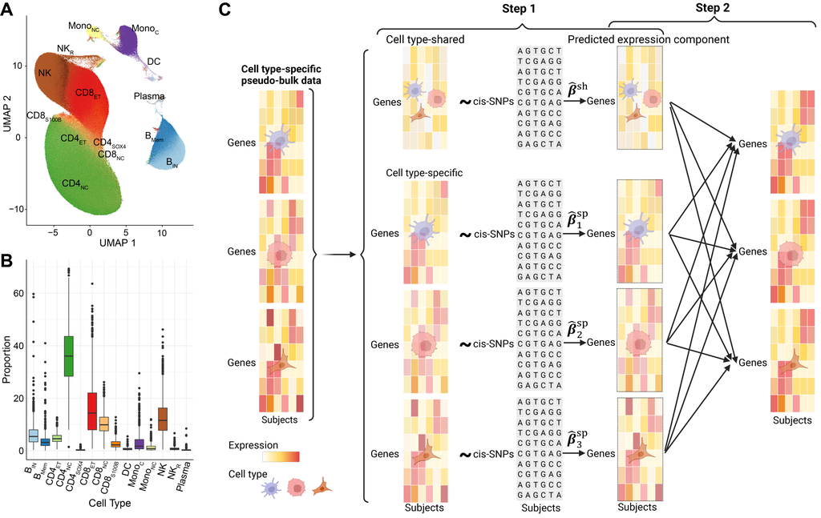

OneK1K-TWAS framework

# 2. Installation

```r
library(devtools)
install_github("FeiQin92/OneK1K-TWAS")
```

# 3. Download example data for building prediction models

Download the example data from *[Example_data.zip](https://www.dropbox.com/scl/fo/iksauut206yrep2ouaz9a/APvZfl_XNHT665xJTlHPJw4?rlkey=hz2kc8p93h2jlhk2nplp32h6t&st=5nuvkq2i&dl=1)*.

```
--Cov
   --genexp_*: Covariates to adjust in each cell type, included sex, age, the top six principal component (PC) scores derived from host genotypic data, and the top two probabilistic estimation of expression residuals (PEER) factors calculated from the expression data.
--Exp
   --ENSG00000000457
       --snpexp: Genotype matrix. Each row is a individual, each column is a cis-SNP for gene ENSG00000000457 (located ±1 Mb of the gene).
       --snppos: A tab-delimited txt file containing snp information with six columns: 1) Chromosome; 2) SNP ID (e.g., 1_168818869); 3) location CM (not exactly necessary for TWAS) 4) Location on chromosome; 5) Allele 1; 6) Allele 2.
       --y
           --genexp_*: Pseudo-bulk expression value for gene ENSG00000000457 in each cell type.
--results: Folder storing temporary files.
--weights: Weights files utlized for TWAS analysis.
```

# 4. Generating prediction models

A two-step procedure was implemented to generate an expression prediction model for each gene in each cell type. In the first step, separate models were built using cis-SNPs to predict the shared and cell type-specific gene expression components across all 14 immune cell types. This was achieved through the elastic net, a regularized regression method that balances model complexity and predictive accuracy. In the second step, gene expression within each targeted cell type was predicted using models integrating the predicted shared and cell type-specific expression components from the first step. Finally, weight vectors for each gene and cell type were derived from these models and applied in TWAS.

## 4.1 Fitting hom and het components respectively

For a given gene in each subject and each cell type, we define the shared expression component as the average expression across all cell types. The cell type-specific expression component was then computed as the original expression minus the shared expression component. These shared and specific expression components were then modeled using the cis-SNPs for this gene.

```r
setwd("C:\\Users\\qinf2\\Downloads\\Example_data2")
library(data.table)
genename <- "ENSG00000000457"
X1 <- paste0("Exp/", genename, "/snpexp")
Y1 <- paste0("Exp/", genename, "/y/")
cov1 <- "Cov/"
Out1 <- "results/"
SNP1 <- paste0("Exp/", genename, "/snppos.txt")
Pre1 <- genename
#################################### First step ######################################
########################  Fitting hom and het components #############################
######################################################################################

library(scTWAS)
hom_het_model(X_file=X1,
              Y_file_dir=Y1,
              cov_file_dir=cov1,
              out_dir=Out1,
              snps=SNP1,
              gene_name=Pre1)

# X_file: Genotype matrix, individuals are row names, no column names.
# Y_file_dir: Direction containing only the expression files. Individuals are row names,
#             no column names.
# cov_file_dir: Cov file direction, should share the same prefix as the expression files.
# out_dir: Output CV predictors and other coefficients.
# snps: A tab-delimited txt file containing snp information. Six columns.
# gene_name: Add this prefix to all the saved results files
```

## 4.2 Fitting models using hom and het components generated in the first step

```r
################################### Second step ######################################
######  Fitting models using hom and het components generated in the first step ######
######################################################################################
setwd("C:\\Users\\qinf2\\Downloads\\Example_data2")
Model_fit(Gname=genename)
```

## 4.3 Combing coefficients from above two steps and prepare for weights file

```r
######################################################################################
###### Combing coefficients from above two steps and prepare for weights file   ######
######################################################################################
setwd("C:\\Users\\qinf2\\Downloads\\Example_data2")
Weights_pre(Gname=genename, in_dir="results/")
```

```
## [1] "1-th tiss"
## [1] "2-th tiss"
## [1] "3-th tiss"
## [1] "4-th tiss"
## [1] "5-th tiss"
## [1] "6-th tiss"
## [1] "7-th tiss"
## [1] "8-th tiss"
## [1] "9-th tiss"
## [1] "10-th tiss"
## [1] "11-th tiss"
## [1] "12-th tiss"
## [1] "13-th tiss"
## [1] "14-th tiss"
```

## 4.4 Generating weights files required for FUSION TWAS

```r
######################################################################################
############# Generating weights files required for FUSION TWAS ######################
######################################################################################
setwd("C:\\Users\\qinf2\\Downloads\\Example_data2")
Weights_gen(Gname=genename, in_dir="results/", out_dir="weights/")
```

The output prediction models will be stored in direction of “….weights/”. Each gene in each cell type will have a .RDat file, which includes important files of

```
--snp: A file containing snp information with six columns: 1) Chromosome; 2) SNP ID (e.g., 1_168818869); 3) Status (not exactly necessary for TWAS) 4) Location on chromosome; 5) Allele 1; 6) Allele 2.
--wgt.matrix: Weights matrix with rownames of SNP ID. Three columns are included showing weights for cis-SNPs from three models  “targetC” , “S+targetC” , and “S+allC” respectively.
```

# 5. Predictions models available for all 14 cell types

To identify more susceptibility genes through TWAS, we implemented three distinct elastic net-based approaches to build gene expression prediction models for each cell type: 1) the traditional ‘targetC’ model, which predicts expression using data only from the targeted cell type; 2) the ‘S+targetC’ model, following Thompson et al., which incorporates both shared and cell type-specific expression components for the targeted cell type; and 3) a novel ‘S+allC’ model proposed by us, which integrates shared and cell type-specific expression components across all cell types to further improve prediction performance in the targeted cell type. *[Prediction models](https://www.dropbox.com/scl/fi/7bou9lku437k47uqcma5t/weights_org.tar?rlkey=4ta9pxzzgxs7te1bqx9k7jbvm&st=ry2v6tnb&dl=1)* for all 14 cell types have been provided according to the the format requirements of *[FUSION](https://github.com/gusevlab/fusion_twas)*.

14 Cell type: “CD4_ET”, “NK”, “CD4_NC”, “CD8_S100B”, “CD8_ET”, “B_IN”, “CD8_NC”, “B_Mem”, “NK_R”, “Mono_NC”, “Mono_C”, “DC”, “Plasma”, “CD4_SOX4”.

Models were compared (see table below) based on the number of genes selected in each model if prediction performance R2 > 0.01. Finally, genes with prediction performance R2 > 0.01 in either of these three models were retained for further TWAS analyses (“Pooled” column). More details about the prediction accuracy abs_R has been provided in *[Prediction_accuracy_R_data.csv](https://www.dropbox.com/scl/fi/fh0adwhqc7higr26jaan1/Prediction_accuracy_R_data.csv?rlkey=krsxawc05jups57n40ebpmw2y&st=u2ukx6bu&dl=1)*.

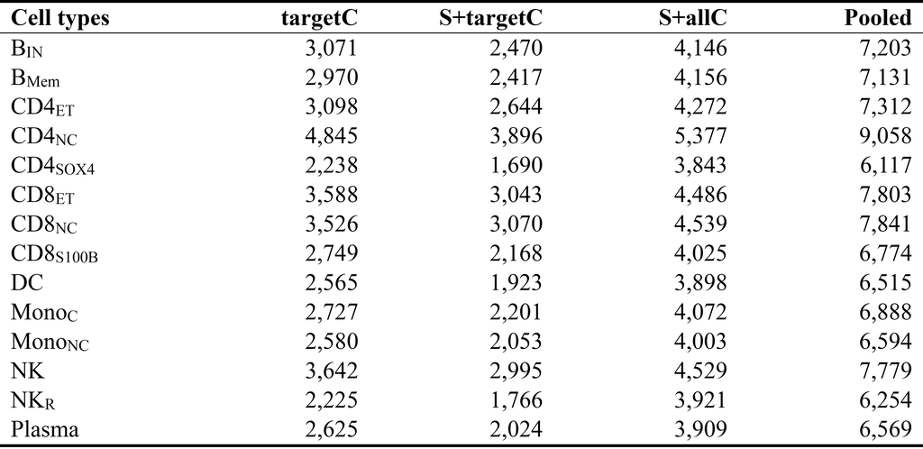

Prediction Accuracy

# 6. Preparing GWAS summary data

For each GWAS summary data, 4 columns are required including:  
1. SNP – SNP identifier (e.g., 1_168818869).  
2. A1 – first allele (effect allele).  
3. A2 – second allele (other allele).  
4. Z – Z-scores, sign with respect to A1.

The GWAS summary statistics are publicly available via: the Breast Cancer Association Consortium [https://bcac.ccge.medschl.cam.ac.uk] for breast cancer; the Open GWAS database [https://gwas.mrcieu.ac.uk] for prostate cancer (accession number: ieu-b-85), and ovarian cancer (accession number: ieu-a-1120); the European Bioinformatics Institute GWAS Catalogue [https://www.ebi.ac.uk/gwas] for lung cancer (accession number: GCST004748), and endometrial cancer (accession number: GCST006464); the database of Genotypes and Phenotypes (dbGaP) with access number phs000876.v1.p1 for melanoma.

# 7. Performing TWAS using predictions models and GWAS summary data

Analysis scripts for FUSION_TWAS for each of three prediction models were also provided.

```
----FUSION_targetC.R
----FUSION_targetC.swarm
----FUSION_S_targetC.R
----FUSION_S_targetC.swarm
----FUSION_S_allC.R
----FUSION_S_alltargetC.swarm
```

The only difference for three R files is the “force_model” in the function. In each .swarm file, the 2th column is the index for chromosome, the 3th column is the index for cell type.